# A meta-analysis on global change drivers and the risk of infectious disease - Supplemental RMarkdown

For BC, CC, and IS, all fail-safe N values are above the Threshold for large amount of studies (5*Nstudies + 10). For HLC, the Orwin method was below the threshold value; however, Rosenthal and Rosenberg are 3 and 4 orders of magnitude greater than the threshold value, respectively. For CP, the Orwin method was below the threshold value, but Rosenthal and Rosenberg values were >7x larger than the threshold valus. So, for all GCD, this evidence indicates that the analyses may be robust with respect to publication bias as such a large number of statistically non-significant results is unlikely to exist.

```r
subdat <- fulldat2 %>%
  filter(!is.na(SMDH_yi),
         !is.na(SMDH_viC))
subdat <- split(subdat, subdat$Global.Change.Driver)

hldn <- data.frame(GCD = as.character(paste(rep(0,times = 5))),
                  Rosenthal = rep(0,times = 5),
                  Orwin = rep(0,times = 5),
                  Rosenberg = rep(0,times = 5),
                  ThreasholdLargeStudyN = rep(0,times = 5))


for(i in 1:length(subdat)){
  hldn$GCD[i] = names(subdat)[i]
  hldn$Rosenthal[i] = fsn(yi = subdat[[i]]$SMDH_yi,
                         vi = subdat[[i]]$SMDH_viC,
                         type = "Rosenthal")$fsnum
  hldn$Orwin[i] = fsn(yi = subdat[[i]]$SMDH_yi,
                     vi = subdat[[i]]$SMDH_viC,
                     type = "Orwin",
                     target = 0.1)$fsnum
  hldn$Rosenberg[i] = fsn(yi = subdat[[i]]$SMDH_yi,
                         vi = subdat[[i]]$SMDH_viC,
                         type = "Rosenberg")$fsnum
  hldn$ThreasholdLargeStudyN[i] = 5*length(unique(subdat[[i]]$Citation.number)) + 10
}

hldn
```

```
##   GCD Rosenthal Orwin Rosenberg ThreasholdLargeStudyN
## 1  BC    108984  3126     57048                   395
## 2  CC    115713  1955   8838399                   985
## 3  CP      4550   429     11292                   630
## 4 HLC   3045228   681  55975776                  2550
## 5  IS     24265  1962       847                   490
```

Leave one out analysis to test for robustness of our analyses. For loop is not run due to time constraints, but code is presented. Leave one out analyses suggests that our results are robust to removal of individual studies.

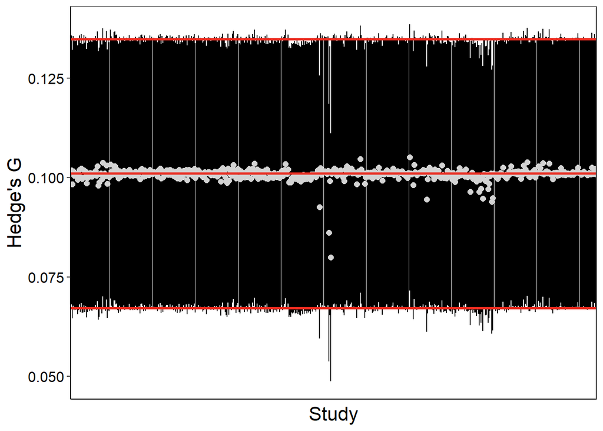

```r
#
# subdat = subgranmod = NULL
# hld = data.frame(beta = 0,
#                  se = 0)

# for(i in 1:length(unique(fulldat2$Citation.number))) {
#   subdat = subgranmod = NULL
#   subdat <- fulldat2 %>%
#     filter(Citation.number != unique(fulldat2$Citation.number)[i])
#   subgranmod <- rma.mv(SMDH_yi, SMDH_viC,
#                        random = list(~1|Citation.number, ~1|ind_id),
#                        data = subdat)
#   hld[i,1] = subgranmod$beta[1]
#   hld[i,2] = subgranmod$se
# }
# saveRDS(hld, "G:/Shared drives/GCD of Disease/Final_dat/Leave1Outdat.RDS")

hld <- readRDS("./Data/Leave1OutdatNEW.RDS")

l1o <- ggplot(hld, aes(x = 1:nrow(hld), y = beta))+
  geom_errorbar(aes(ymin = beta - se, ymax = beta + se), width = 0)+
  geom_point(color = "light grey", size = 2)+
  geom_hline(yintercept = 0.1010, color = "#EA2B1F", linewidth = 1)+
  geom_hline(yintercept = 0.1010 + 0.0338, color = "#EA2B1F", linewidth = 1)+
  geom_hline(yintercept = 0.1010 - 0.0338, color = "#EA2B1F", linewidth = 1)+
  scale_x_continuous(limits = c(0,580), expand = c(0,0))+
  labs(x = "Study",
       y = "Hedge's G")+
  theme_JR()+
  theme(axis.text.x = element_blank(),
        axis.ticks.x = element_blank())
l1o
```

```r
ggsave("./Figures/Leave1out.tiff",
       dpi = 300,
       width = 5,
       height = 4.65,
       units = "in")
```

Forest plots to show distribution of effect sizes and variances among global change drivers.

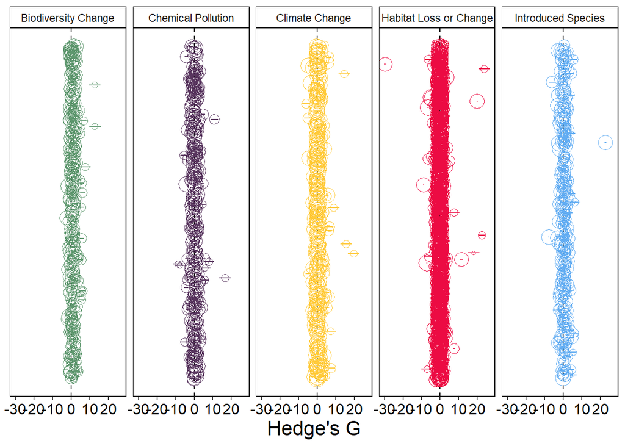